# Lecture 4: Survival Analysis and Churn Prediction

When Will Customers Leave — and Who Is Most at Risk?

## Motivating Problem

**Tip**

**Setting:** A subscription firm observes customer event times with right-censoring. Which ones are likely to churn next month, and how quickly does the overall subscriber base decay?

**Learning Objectives**

- Compute a Kaplan-Meier survival curve step by step
- Interpret conditional vs. unconditional churn probabilities
- Read the median survival time off a KM curve
- Read a Cox model output and understand hazard ratios
- Handle censored observations correctly
- Detect when the proportional hazards assumption fails

## The Censoring Problem

**Who is censored:** everyone still active on the analysis date, **at their current age** (months since sign-up).  
Joined 32 months ago, still active → censored at 32.  
Joined 4 months ago, still active → censored at 4.  
Also anyone **lost to follow-up** (data gap, account migration), at their age when the record ends.

**Why it matters:**  
Keeping only the customers who cancelled causes **survival bias**.  
Treating censored as churned overstates churn.  
KM uses censored customers correctly.

**Warning**

Censoring ≠ missing data. It’s a known lower bound on the churn age.

## Calendar Time vs Customer Age

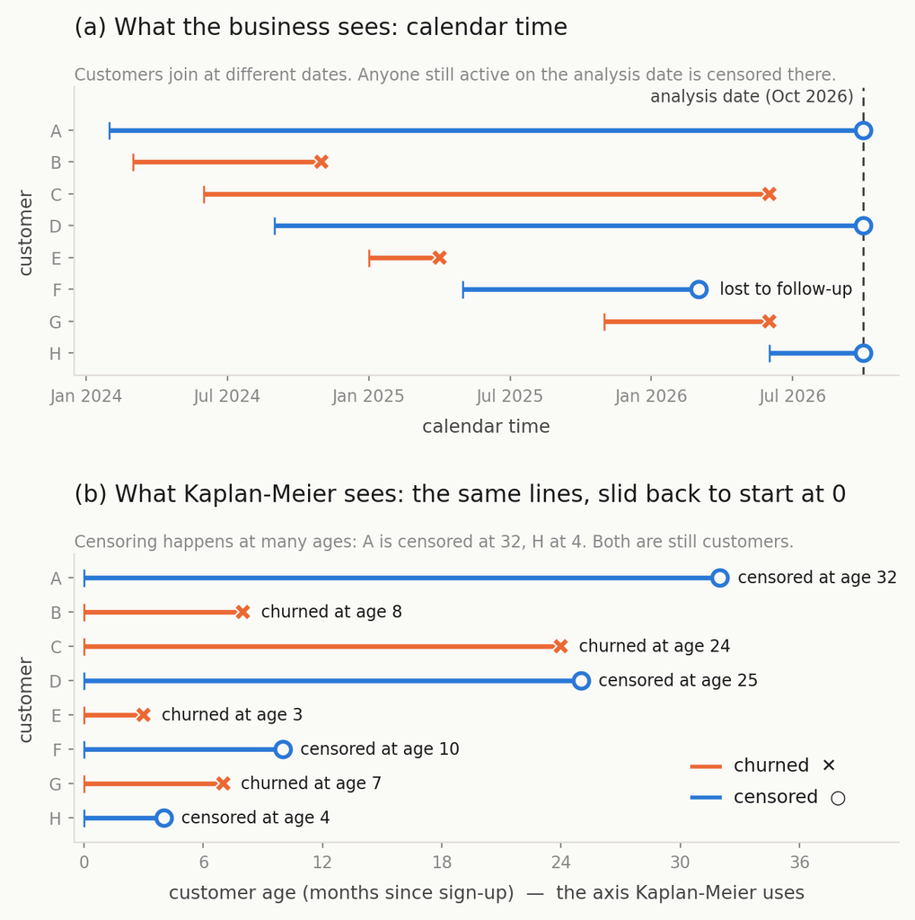

## KM on the Same Eight Customers

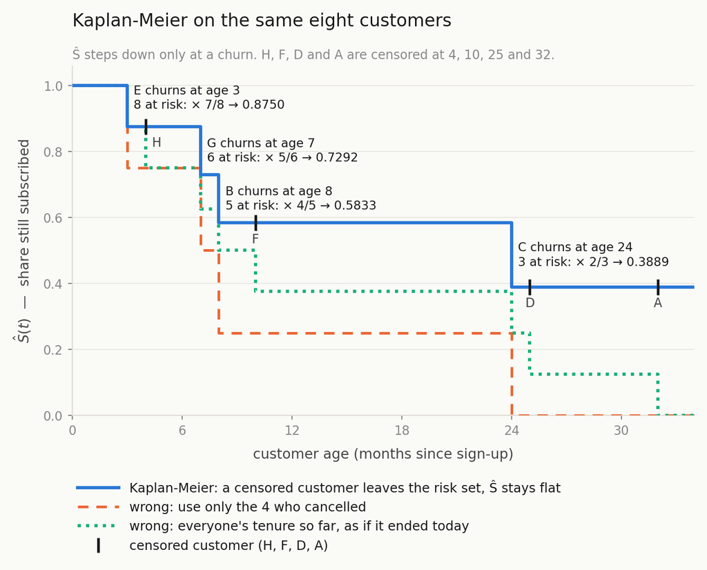

KM assumes censoring is **non-informative**: a customer censored at age $t$ would have churned like those still at risk at $t$, so newer cohorts are assumed to churn like older ones did.

## The Hazard: a Rate Among Those Still at Risk

$T$ = a customer’s **churn time**. Survival: $S(t) = P(T > t)$.

$$h_t = \frac{d_t}{n_t} = \frac{\text{churned at } t}{\text{still at risk just before } t}$$

The **hazard** $h(t)$ is this for an instant: the rate at which customers who survived to $t$ churn right at $t$.

- **Conditional on survival** — the denominator is those still at risk, never the original cohort.
- **A rate, not a probability** — “per month”; over a short $\Delta t$, $P(\text{churn}) \approx h(t)\,\Delta t$.

**Tip**

**Churn rate** = a per-month hazard (“10% cancel every month”). **Churn probability** = a cumulative share, $1 - \hat{S}(t)$.

## Kaplan-Meier Estimator

At each event time $t_j$ where $d_j$ customers churn out of $n_j$ at risk:

$$\hat{S}(t) = \prod_{j:\; t_j \leq t} \frac{n_j - d_j}{n_j}$$

Cumulative product of conditional survival probabilities. $t$ is customer **age** (months since sign-up), not a calendar month.

| Age $t$ (months) | At risk $n_j$ | Churned $d_j$ | $(n_j - d_j)/n_j$ | $\hat{S}(t)$ |
| --- | --- | --- | --- | --- |
| 2 | 200 | 8 | 192/200 = 0.960 | **0.9600** |
| 5 | 185 | 12 | 173/185 = 0.9351 | **0.8977** |
| 9 | 160 | 20 | 140/160 = 0.8750 | **0.7855** |

## KM Is a Step Function

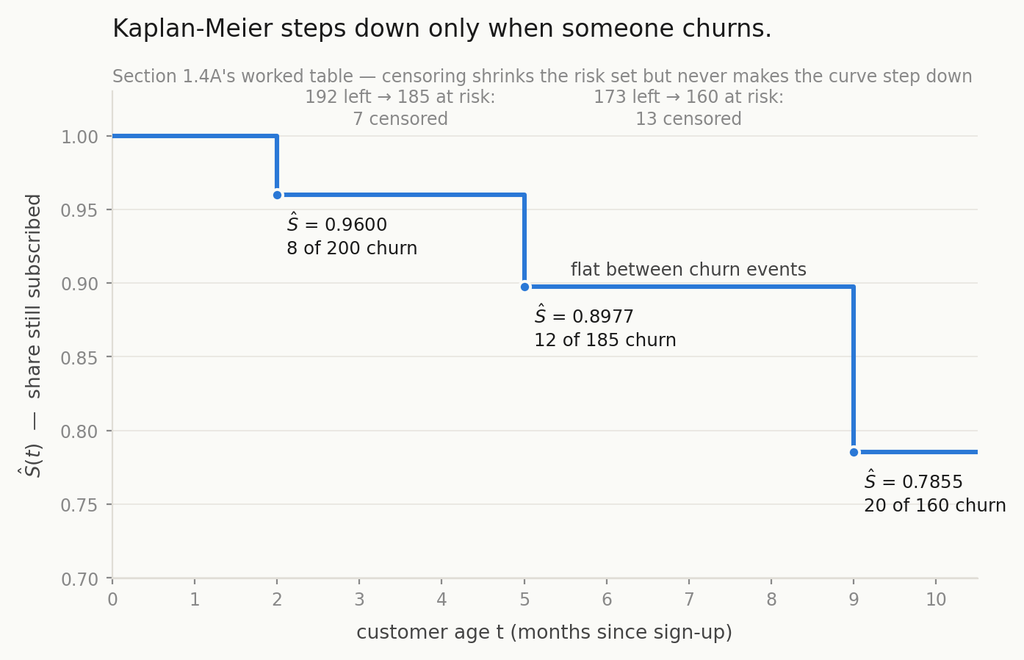

Flat between churn events. Censored customers shrink the risk set but never make the curve step down.

## Hazard and Survival on One Axis

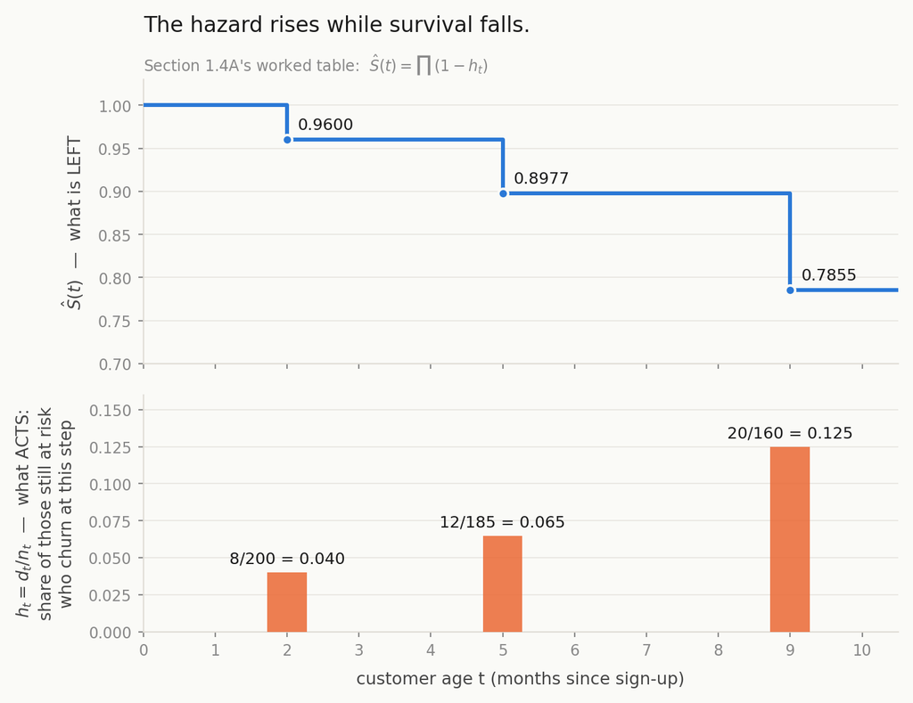

$\hat{S}(t) = \prod_{t_j \leq t} (1 - h_{t_j})$ — survival is what is left after the hazard acts.

## Conditional Churn Probability

“Of customers who survived to month 5, what fraction churn by month 9?”

$$P(\text{churn between } t_1, t_2 \mid T > t_1) = 1 - \frac{\hat{S}(t_2)}{\hat{S}(t_1)}$$

$T$ = churn time.

**Example:**

$$1 - \frac{\hat{S}(9)}{\hat{S}(5)} = 1 - \frac{0.7855}{0.8977} = 1 - 0.875 = \mathbf{12.5\%}$$

**Tip**

Very different from the unconditional churn probability: $1 - \hat{S}(9) = 21.5\%$.  
The conditional probability is what a retention campaign manager needs.

## Median Survival Time

$\hat{S}(t)$ is a **step** function — it jumps past $0.5$ rather than touching it, so the median needs a stated convention:

$$\text{median} = \min\{\,t : \hat{S}(t) \leq 0.5\,\}$$

The **first** $t$ at or below $0.5$ — not the $t$ before the crossing, and not an interpolation.

**Example**

$\hat{S}(6) = 0.55$ (above)  
$\hat{S}(7) = 0.46$ (at-or-below → **median = 7 months**)

**Edge cases**

$\hat{S}(t)$ exactly $0.5$ → that $t$ is the median (rule is $\leq$).

Curve never reaches $0.5$ → **“median not reached”**, not the last observed time.

## Cox Proportional Hazards Model

Baseline hazard × covariate effect:

$$h(t \mid \mathbf{x}) = h_0(t) \cdot \exp(\boldsymbol{\beta}^\top \mathbf{x})$$

**Hazard Ratio (HR):**

$$\text{HR}_k = \frac{h_0(t)\,e^{\beta_k (x+1)}}{h_0(t)\,e^{\beta_k x}} = e^{\beta_k}$$

$h_0(t)$ cancels → same ratio at every $t$.

For $c$ units of $x_k$:

$$\text{HR} = e^{c\,\beta_k} = (e^{\beta_k})^c$$

**Interpretation:**

$\text{HR} > 1$: higher hazard (faster churn)  
$\text{HR} < 1$: protective (slower churn)  
$\text{HR} = 1$: no effect

Always **multiplicative**, never additive.

A ratio of **hazards**, not of churn probabilities: HR = 1.42 turns 21.5% churned by month 9 into 29.0% (1.35×), since $S(t \mid x) = S_0(t)^{\text{HR}}$.

## HR Compounding Example

$\text{HR}_{\text{support tickets}} = 1.35$ per ticket.  
Customer has 2 support tickets:

$$\text{HR} = e^{2\,\beta} = (e^{\beta})^2 = 1.35^2 = \mathbf{1.8225}$$

This customer has **82.25% higher hazard** than a baseline customer.

**Warning**

HR does NOT compound additively: it is NOT $2 \times 1.35 = 2.70$.  
Exponentiation makes it multiplicative.

## Scope and Limitations

**Estimands**

- $\hat{S}(t)$: non-parametric survival probability at time $t$
- Conditional churn probability over $[t_1, t_2]$
- Hazard ratio per covariate: $\text{HR}_k = e^{\hat{\beta}_k}$

**Identification assumptions**

Cox HRs are **associational**. A covariate with $\text{HR} > 1$ predicts faster churn but does not establish causation. Causal identification requires randomization (Lecture 7).  
**Self-selection** is the live case: customers *choose* their plan, so an annual-vs-monthly KM gap confounds the plan’s effect with the kind of customer who picks it. Controlling for `plan_type` adjusts only for what you measured, never for the intent that did the selecting.  
**Proportional hazards** must hold: test with Schoenfeld residuals (`check_assumptions()`); the log(−log Ŝ) vs log t plot asks the same question by eye (parallel = a constant log HR apart).

## Checkpoint

KM table (from the Kaplan-Meier slide): events at months 2, 5 and 9, with $\hat{S}$ = 0.9600, 0.8977, 0.7855.

1. A customer has been active for 14 months. The KM table has no event at month 14. What is $\hat{S}(14)$?
2. Compute the conditional churn probability from month 2 to month 9.
3. $\text{HR}_{\text{support tickets}} = 1.42$ per ticket. A customer filed 3 tickets. What is their relative hazard versus a customer with 0 tickets?
4. A customer has $\hat{S}(24) = 0.32$. In plain English, what does this mean?
5. “Customers who call support churn faster, so we should stop offering phone support.” What’s wrong with this reasoning?

Answers in the lecture notes, under “Slide Checkpoint Answers” (numbered to match this slide).